# NLP Workshop

# Setup

link to lesson plan: https://ucdavisdatalab.github.io/workshop-nlp-healthcare/

#### a. objectives

```
1. Show how to store and clean text data with the 'tm' package
2. Introduce Bag of Words representation of documents
3. Demonstrate how to create and use a DocumentTermMatrix
4. Explain and demonstrate TF-IDF weighting
5. Explain PCA and its applications for corpus exploration
```

#### b. packages needed

In R, and most programming languages, there are many packages - code written by other people to help with certain tasks. For this workshop we will be using two packages - ‘tm’ and ‘ggplot2’. The ‘tm’ - text mining - package has methods for mining text with R including importing data, storing corpora, applying operations on corpora (such as common preprocessing methods), and document term matrices. The ‘ggplot2’ package has functions related to plotting and visualizing data.

Run this command if you don’t already have these packages installed.

```r
install.packages('tm')
install.packages('ggplot2')
install.packages('Matrix')
```

Once the packages are installed, load them into your R environment.

```r
library('tm')
```

```r
library('ggplot2')
library('Matrix')
```

You can find the documentation for the package [online](https://cran.r-project.org/web/packages/tm/tm.pdf)  
Within R/RStudio you can browse function documentation with the following syntax.

```
?TermDocumentMatrix
```

#### c. data for this workshop

For this workshop, we are looking at a set of abstracts of medical journal articles related to breast cancer. We have 714 abstracts, stored in a csv, with duplicates. We would like to get the key words from each abstract, as well as visualize / check for groupings of abstracts in two dimensions.

```r
data <- read.csv(url("https://ucdavisdatalab.github.io/workshop-nlp-healthcare/abstracts.csv"))
```

```r
head(data)
```

```
##   authors year
## 1         2008
## 2         2014
## 3         2015
## 4         2016
## 5         2016
## 6         2017
##                                                                                                                                                                                                                                                                                                          …
## 1                                                                                                                                                     The UK Standardisation of Breast Radiotherapy (START) Trial B of radiotherapy hypofractionation for treatment of early breast cancer: a randomised …
## 2 Erratum: Effect of radiotherapy after mastectomy and axillary surgery on 10-year recurrence and 20-year breast cancer mortality: meta-analysis of individual patient data for 8135 women in 22 randomised trials (The Lancet (2014) 383(9935) (2127–2135)(S0140673614604888)(10.1016/S0140-6736(14)6048…
## 3                                                                                                                                                                                                                   Proceedings of the American Society for Radiation Oncology 57th Annual Meeting, ASTRO…
## 4                                                                                                                                                                                              Late-Breaking Abstracts from the 57th Annual Meeting of the American Society for Radiation Oncology, ASTRO…
## 5                                                                                                                                                                                                                                       Proceedings of the American Society for Radiation Oncology, ASTRO…
## 6                                                                                                                                                                                                                                                            2017 ASTRO Annual Meeting Late-Breaking Abst…
##                                                       journal
## 1                                                  The Lancet
## 2                                                  The Lancet
## 3 International Journal of Radiation Oncology Biology Physics
## 4 International Journal of Radiation Oncology Biology Physics
## 5                 International Journal of Radiation Oncology
## 6 International Journal of Radiation Oncology Biology Physics
##                                                                                                                                                                                                                                                                                                          …
## 1 Background: The international standard radiotherapy schedule for early breast cancer delivers 50 Gy in 25 fractions of 2·0 Gy over 5 weeks, but there is a long history of non-standard regimens delivering a lower total dose using fewer, larger fractions (hypofractionation). We aimed to test the …
## 2                                                                                                                                                                                                                                                                                                        …
## 3                                                                                                                                                                                                                                                                                                        …
## 4                                                                                                                                                                                                                                                                                                        …
## 5                                                                                                                                                                                                                                                                                                        …
## 6                                                                                                                                                                                                                                                                                                        …
```

We have a dataframe with 714 rows, each row referring to a different abstract. For each abstract we have the authors, year published, title of the paper, name of the journal, and the full text.

Let’s look at the text from the first abstract

```r
data$text[[1]]
```

```
## [1] Background: The international standard radiotherapy schedule for early breast cancer delivers 50 Gy in 25 fractions of 2·0 Gy over 5 weeks, but there is a long history of non-standard regimens delivering a lower total dose using fewer, larger fractions (hypofractionation). We aimed to test th…
## 714 Levels: 85 Female patients with early stage breast cancer, i.e., Stage I and II were treated by limited surgery followed by radical radiation therapy at Massachusetts General Hospital between January, 1956, and December, 1974. Patients included those who were medically inoperable or who refus…
```

Notice that within the text there are a variety of potential issues. For example, some words are capitalized, there is punctuation, weird symbols, and numbers. For many NLP methods, we want to normalize the texts to get around these issues. The ‘tm’ package has several built in features for normalizing text. The first step is to load the text into a ‘corpus’ object.

# Preprocessing

#### a. Load the text column into a ‘corpus’ object

```r
mycorpus <- Corpus(VectorSource(data$text))
inspect(head(mycorpus))
```

```
## <<SimpleCorpus>>
## Metadata:  corpus specific: 1, document level (indexed): 0
## Content:  documents: 6
##
## [1] Background: The international standard radiotherapy schedule for early breast cancer delivers 50 Gy in 25 fractions of 2·0 Gy over 5 weeks, but there is a long history of non-standard regimens delivering a lower total dose using fewer, larger fractions (hypofractionation). We aimed to test th…
## [2] EBCTCG (Early Breast Cancer Trialists' Collaborative Group). Effect of radiotherapy after mastectomy and axillary surgery on 10-year recurrence and 20-year breast cancer mortality: meta-analysis of individual patient data for 8135 women in 22 randomised trials. Lancet 2014; 383: 2127–35—Durin…
## [3] The proceedings contain 2121 papers. The topics discussed include: radiation treatment parameters and late gastrointestinal toxicity in cervical cancer patients treated with image guided high-dose-rate brachytherapy; the effect of pelvic radiation therapy on vaginal brachytherapy cylinder siz…
## [4] The proceedings contain 12 papers. The topics discussed include: dexamethasone versus placebo in the prophylaxis of radiation-induced pain flare following palliative radiation therapy for bone metastases: a double-blind randomized, controlled, superiority trial; hypofractionated versus conven…
## [5] The proceedings contain 2300 papers. The topics discussed include: a phase III randomized control trial comparing skin-sparing helical tomotherapy versus 3D-conformal radiation therapy in early-stage breast cancer: acute and late skin toxicity outcomes; longitudinal analysis of patient-report…
## [6] The proceedings contain 16 papers. The topics discussed include: tumor treating fields (TTFields)- a novel cancer treatment modality: translating preclinical evidence and engineering into a survival benefit with delayed decline in quality of life; a randomized controlled trial evaluating the …
```

#### b. Preprocess the corpus object

Use the tm_map function to apply a transformation on each element of the corpus object.  
Alternatively use the tm_parLapply function to do the same in parallel.

```r
mycorpus <- tm_map(mycorpus, tolower)
mycorpus <- tm_map(mycorpus, removePunctuation, ucp=TRUE)
mycorpus <- tm_map(mycorpus, removeNumbers)
mycorpus <- tm_map(mycorpus, removeWords, stopwords("en"))
```

Now that we have normalized the text, lets look at the first abstract again.

```r
mycorpus[[1]]$content
```

```
## [1] "background  international standard radiotherapy schedule  early breast cancer delivers  gy   fractions   gy   weeks     long history  nonstandard regimens delivering  lower total dose using fewer larger fractions hypofractionation  aimed  test  benefits  radiotherapy schedules using fraction…
```

It looks ‘normalized’ but how do we model this? how do we apply NLP algorithms on it?

# The Bag of Words Representation

Consider:  
what is a text document to a computer?  
What can it do with a sequence of characters?

In order for us to apply statistical methods on a document, we need a representation of texts that is easy for a computer to process, but still encodes information related to that text’s content. One such representation is the Bag of Words format.

Bag of Words is a way of representing a document that encodes a document as a ‘bag’ of its tokens. The document is represented as the words that appeared in the document and the number of times those words appeared. All information about word order is lost in this representation, however, for many NLP methods, this is still an effective representation of the content of the document.

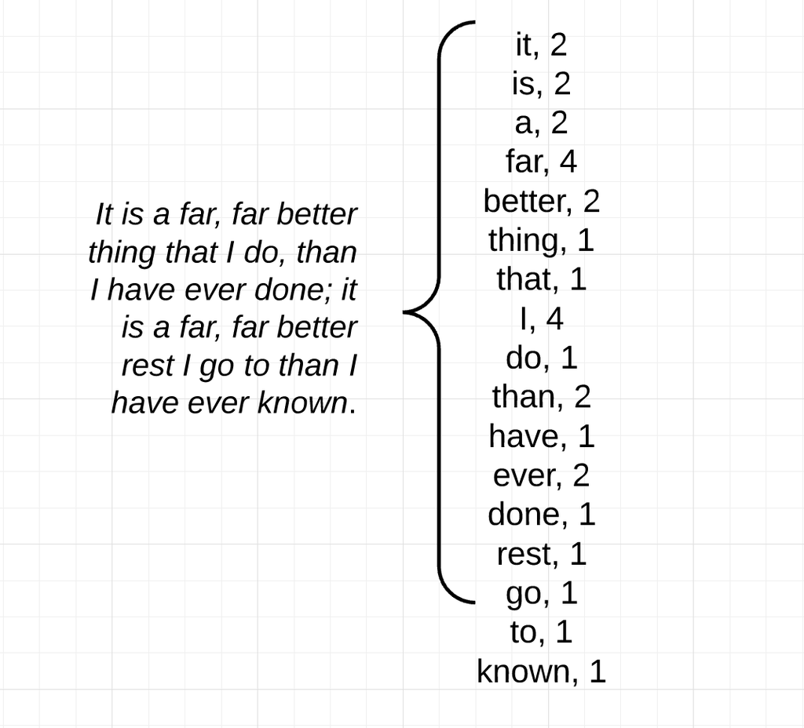

bag of words image

The power of the bag of words representation is that each document can be represented in the same vector space. We do so by defining the vector dimensions to reflect the vocabulary across all the documents. The vectors can then be merged into a matrix called a Document Term Matrix.

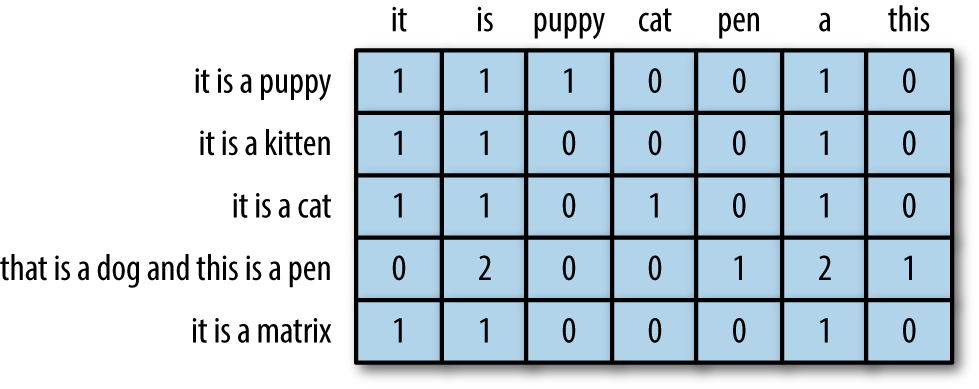

dtm image

# The Document Term Matrix

In brief, a Document Term Matrix:  
- each document is represented by a set of tokens and their counts  
- the order of tokens is not encoded in this representation  
- the basis of many text processing methods, including document classification and topic modeling

In R we can use a DocumentTermMatrix function from the ‘tm’ package to create this structure from our corpus.

#### a. Creating a Document Term Matrix from the corpus object

From the ‘corpus’ object we can create a document term matrix.

```r
mydtm <- DocumentTermMatrix(mycorpus)
```

Note: the DocumentTermMatrix automatically sets all the characters to lower case.

#### b. Exploring with a DTM

A useful tool is the inspect function from the ‘tm’ package.

```r
inspect(mydtm)
```

```
## <<DocumentTermMatrix (documents: 714, terms: 8180)>>
## Non-/sparse entries: 86106/5754414
## Sparsity           : 99%
## Maximal term length: 40
## Weighting          : term frequency (tf)
## Sample             :
##      Terms
## Docs  breast cancer dose patients radiation results therapy treated treatment
##   125      6      3    0        8         0       0       0       0         3
##   18       6      0    4        4         0       1       1       4         1
##   192     12      2    0       17         0       1       1       1         4
##   203     14     29    0        2         6       1       3       4         0
##   207     10      4    2        9         3       1       0       2         1
##   272      7      4    7        7         1       2       1       0         1
##   322      4      1    3        3         1       0       1       2         1
##   323      6      1   11        4         1       0       1       1         8
##   598      5      1    3       13         0       1       1       0         6
##   622      6      6    0       13         1       1       2       0         4
##      Terms
## Docs  years
##   125     2
##   18      0
##   192     3
##   203     6
##   207     5
##   272     0
##   322     0
##   323     0
##   598     5
##   622     2
```

From this format it we can find word counts and document lengths.

```r
document_lengths <- rowSums(as.matrix(mydtm))
word_counts <- colSums(as.matrix(mydtm))
```

We can get a sorted list of the biggest documents.

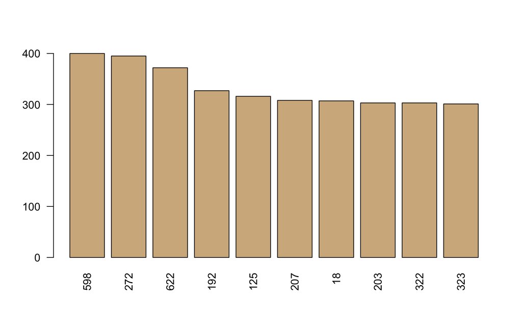

```r
sorted_document_lengths <- sort(document_lengths, decreasing=TRUE)
barplot(sorted_document_lengths[1:10], col = "tan", las = 2)
```

Or a sorted list of words and their frequencies.

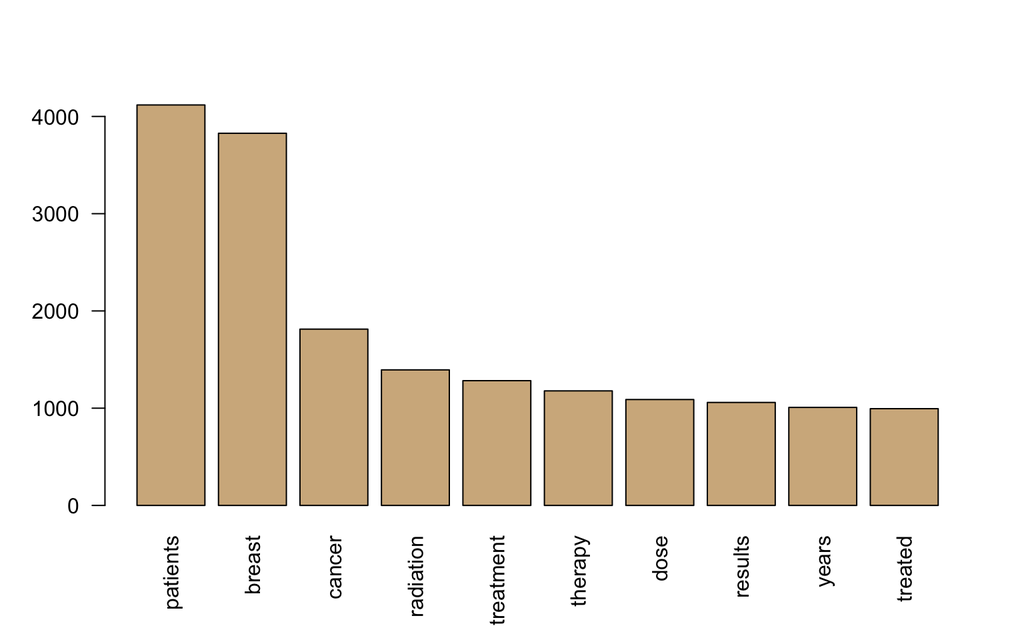

```r
sorted_word_counts <- sort(word_counts, decreasing=TRUE)
barplot(sorted_word_counts[1:10], col = "tan", las = 2)
```

# TF-IDF

TF-IDF stands for term frequency-inverse document frequency. It is a VERY popular method for finding documents relevant to a users search term. It can also be used as an effective (often times better than simple bag of words) representation of documents for statistical modeling of documents in a corpus.

#### a. Intuition behind TF-IDF

TF-IDF combines two attributes that may signal a words importance in a document into a single metric. The first is the ‘term frequency (TF)’ - how often the word appeared within that document. It makes intuitive sense that if a word appears many times in a document, that the document is about something related to that term. The second attribute is the ‘inverse document frequency (IDF)’ - a measure of what proportion of the documents the word appeared in. If a word appears in all documents, its weight should be reduced. Conversely, if a word appears only in few documents, it should be highly weighted for those documents.

#### b. TF-IDF formula

```
tfidf(t,d,D) = tf(t,d) * idf(t,D)
```

Where, tf(t,d) is a function of a terms(t) frequency for a given document(d). And, idf(t,D) is the inverse function of a terms(t) appearance across all the documents(D). There are many variations of functions for tf(t,d) and idf(t,D) that can be used for computing TF-IDF.

#### c. TF-IDF from DTM

Create tf-idf weighted DTM in R

```r
tfidf_dtm <- weightTfIdf(mydtm, normalize=TRUE)
```

#### d. Looking at the results

Inspect the new dtm

```r
inspect(tfidf_dtm)
```

```
## <<DocumentTermMatrix (documents: 714, terms: 8180)>>
## Non-/sparse entries: 86106/5754414
## Sparsity           : 99%
## Maximal term length: 40
## Weighting          : term frequency - inverse document frequency (normalized) (tf-idf)
## Sample             :
##      Terms
## Docs  apbi boost        dose grade group      local    survival   toxicity
##   121    0     0 0.000000000     0     0 0.00000000 0.000000000 0.00000000
##   16     0     0 0.000000000     0     0 0.00000000 0.032447894 0.01528079
##   177    0     0 0.009260951     0     0 0.00000000 0.006907363 0.00000000
##   291    0     0 0.000000000     0     0 0.00000000 0.000000000 0.00000000
##   294    0     0 0.000000000     0     0 0.00000000 0.000000000 0.00000000
##   307    0     0 0.000000000     0     0 0.01274054 0.000000000 0.00000000
##   443    0     0 0.000000000     0     0 0.00000000 0.000000000 0.00000000
##   54     0     0 0.000000000     0     0 0.00000000 0.011578529 0.00000000
##   593    0     0 0.000000000     0     0 0.00000000 0.000000000 0.00000000
##   7      0     0 0.000000000     0     0 0.00000000 0.000000000 0.00000000
##      Terms
## Docs  women years
##   121     0     0
##   16      0     0
##   177     0     0
##   291     0     0
##   294     0     0
##   307     0     0
##   443     0     0
##   54      0     0
##   593     0     0
##   7       0     0
```

Compare the tfidf representation with the tf representation for a single abstract

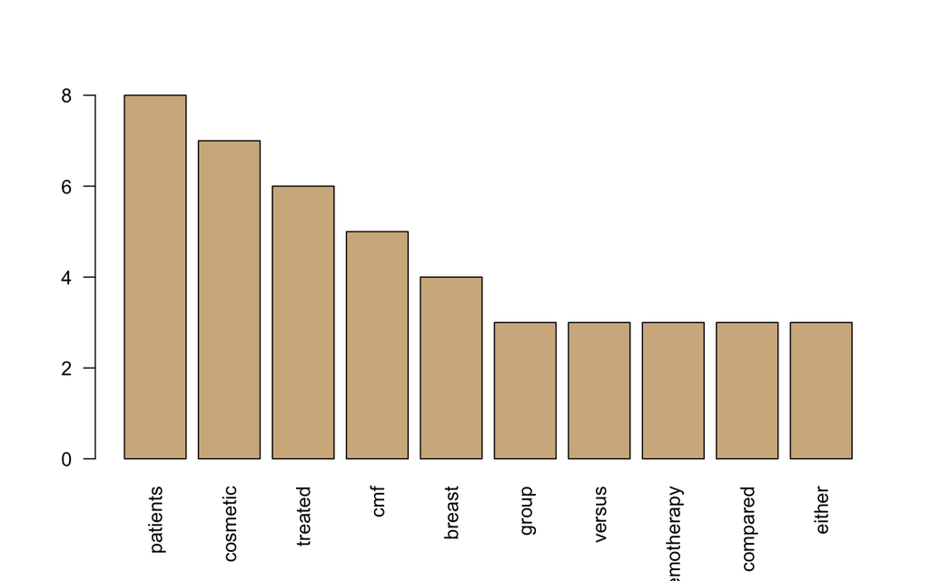

```r
tf_doc10 <- as.matrix(mydtm[10,])
tf <- colSums(tf_doc10)
tfidf_doc10 <- as.matrix(tfidf_dtm[10,])
tfidf <- colSums(tfidf_doc10)
barplot(sort(tf, decreasing=TRUE)[1:10], col = "tan", las = 2)
```

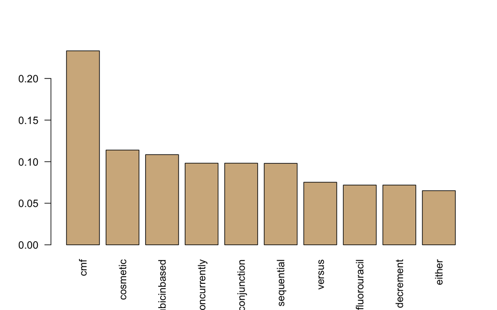

```r
barplot(sort(tfidf, decreasing=TRUE)[1:10], col = "tan", las = 2)
```

# PCA

#### a. Intuition behind PCA

The most straightforward way to visualize the information in the TF-IDF matrix is to plot its columns, but this is unsatisfactory because there are thousands of them, and each column is mostly zeroes (so contains little information):

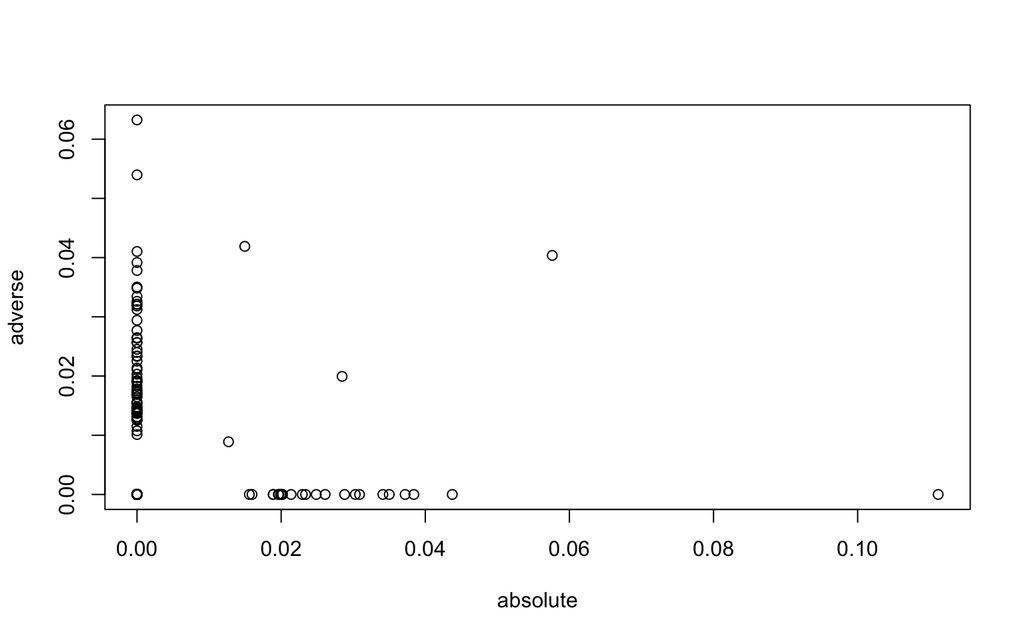

```r
plot(as.matrix(tfidf_dtm[, 1:2]))
```

Our answer is to use principal components analysis (PCA), which rotates the big matrix until we are “looking” down the “direction” (or component) with the most variability. The result is another matrix of equal size to the first, but each column contains information from all of the columns of the original matrix, and they are sorted so that the most important columns are first. We can observe get the most important relationships by focusing on just a few of these “principal components”. Let’s continue with our example:

#### b. Computing PCA

```r
articles <- t(tfidf_dtm)
mypca <- prcomp(articles, center=TRUE, scale=TRUE)
```

#### c. Plotting the abstracts

Add the principal components to the original data:

```r
plotdata <- cbind(data, mypca$rotation)
```

And now plot the abstracts. Each dot in the figure represents one abstract.

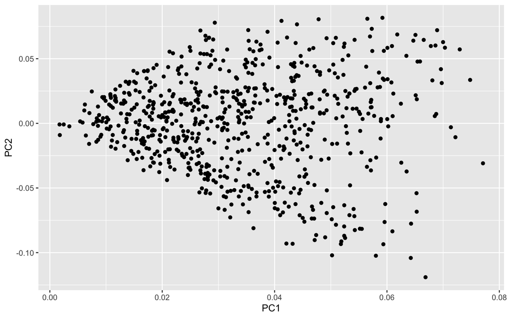

```r
ggplot(plotdata) + aes(x=PC1, y=PC2) + geom_point()
```

Now let’s identify some articles from the plot.

```r
min_index <- order(plotdata$PC1, decreasing=FALSE)
max_index <- order(plotdata$PC1, decreasing=TRUE)

# view the most divergent titles:
plotdata$title[min_index[1:6]]
```

```
## [1] Creation of an episode-based payment model for prostate and breast cancer radiation therapy.
## [2] Signal transduction pathways regulated by CSF-1 receptors modulate the in vitro radiosensitivity of mammary epithelial cells.
## [3] Erratum to: Wang SY, Kelly G, Gross C, et al. Information needs of older women with early-stage breast cancer when making radiation therapy decisions. [Int J Radiat Oncol Biol Phys 2017;98:733-740](S0360301617303097)(10.1016/j.ijrobp.2017.02.001)).
## [4] Molecular radiation therapy in experimental model of advanced prostate cancer using internalizable monoclonal antibody.
## [5] Dna double-strand break repair and induction of apoptosis in relation to late normal tissue responses following radiation therapy for early breast cancer.
## [6] Patient experience survey of early-stage breast cancer patients undergoing whole-breast radiation therapy.
## 710 Levels: “Choosing wisely”: The American society for radiation oncology's top 5 list. ...
```

```r
plotdata$title[max_index[1:6]]
```

```
## [1] Differences in Patterns of Failure in Patients Treated With Accelerated Partial Breast Irradiation Versus Whole-Breast Irradiation: A Matched-Pair Analysis With 10-Year Follow-Up.
## [2] Margin status an indication for accelerated partial breast irradiation in early-stage breast cancers.
## [3] Daily Fractionation of External Beam Accelerated Partial Breast Irradiation to 40 Gy Is Well Tolerated and Locally Effective.
## [4] Accelerated partial-breast irradiation provides equivalent 10-year outcomes to whole breast irradiation: A matched-pair analysis.
## [5] Accelerated partial breast irradiation using sole interstitial multicatheter brachytherapy versus whole breast irradiation for early breast cancer: Five-year results of a randomized phase 3 trial-Part I: Local control and survival results.
## [6] Phase I/II Study Evaluating Early Tolerance in Breast Cancer Patients Undergoing Accelerated Partial Breast Irradiation Treated With the MammoSite Balloon Breast Brachytherapy Catheter Using a 2-Day Dose Schedule.
## 710 Levels: “Choosing wisely”: The American society for radiation oncology's top 5 list. ...
```

Visualize the explained variance. This is the metric that PCA uses to decide which components are the most important.

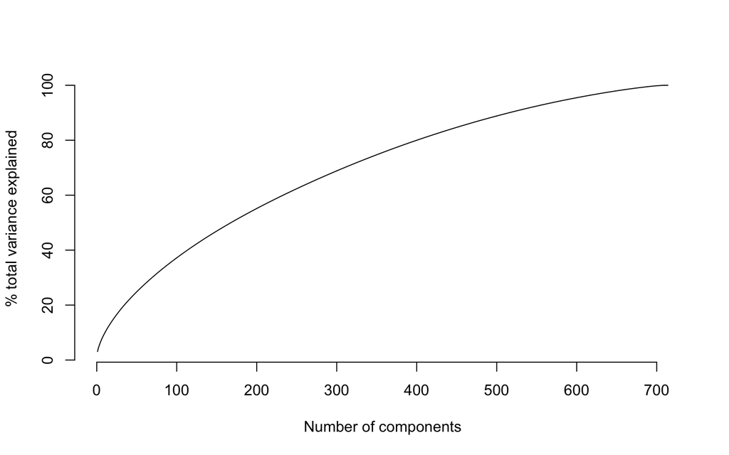

```r
plot(100 * cumsum(mypca$sdev^2) / sum(mypca$sdev^2), type='l', bty='n', ylab="% total variance explained", xlab="Number of components")
```

Let’s add some additional information: a few top terms from each abstract. These are the most characeristic terms from the abstract, as ranked by TF-IDF. We’ll plot the abstracts on the 2nd and 3rd principal components, annotated by the top terms.

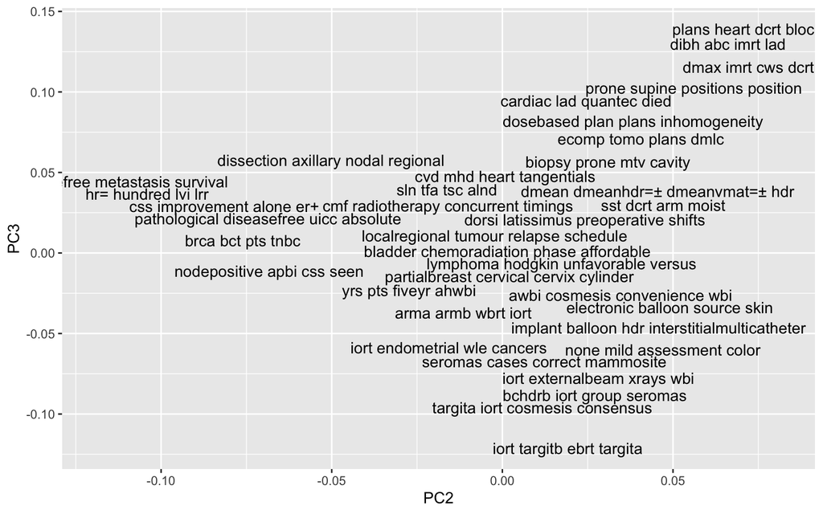

```r
source(url("https://ucdavisdatalab.github.io/workshop-nlp-healthcare/top_terms.R"))
plotdata[['top_terms']] <- top_terms(tfidf_dtm)
ggplot(plotdata) + aes(x=PC2, y=PC3, label=top_terms) + geom_text(check_overlap=TRUE)
```

We’re also going to look at k-means to identify clusters in data. To begin, let’s include some abstracts dealing with cervical cancer from the same journals as the breast cancer abstracts.

```r
cervical <- read.csv(url("https://ucdavisdatalab.github.io/workshop-nlp-healthcare/cervical-abstracts.csv"))
data[["topic"]] <- "breast"
cervical[["topic"]] <- "cervical"
combined <- rbind(data, cervical)
```

Rather than processing the combined abstracts step-by-step, let’s grab a function to replicate the processing we did on the breast cancer abstracts. This time, though, the terms “breast” “cervical”, and “cervix” will be removed prior to the analysis.

```r
source(url("https://ucdavisdatalab.github.io/workshop-nlp-healthcare/get_corpus.R"))
pca_combined <- get_corpus(combined, remove=c("cervical", "cervix", "breast"))
data_combined <- cbind(combined, pca_combined$rotation)
```

We now have a PCA of the combined abstracts, so let’s see how the first few components look:

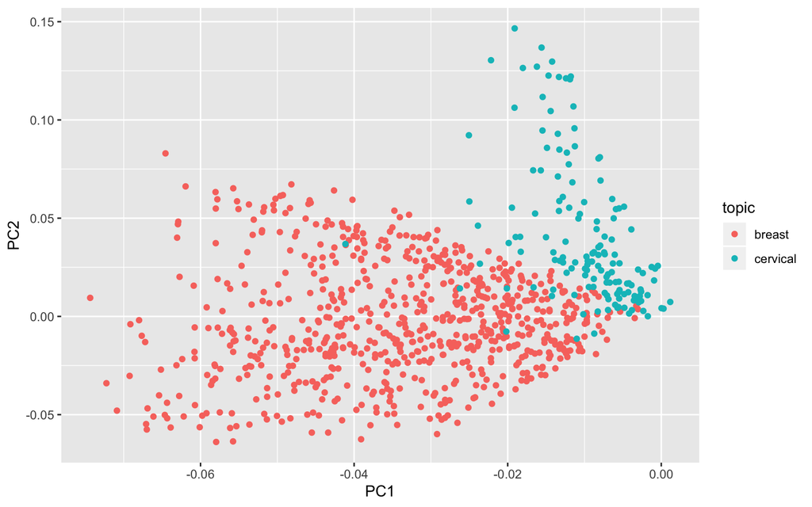

```r
ggplot(data_combined) + aes(x=PC1, y=PC2, color=topic) + geom_point()
```

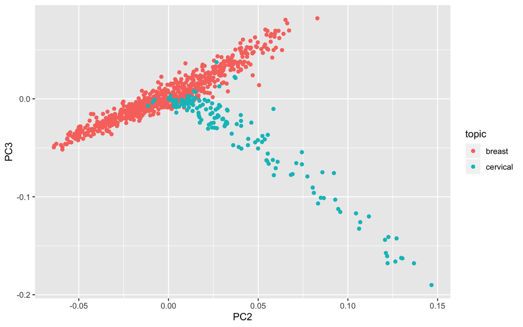

```r
ggplot(data_combined) + aes(x=PC2, y=PC3, color=topic) + geom_point()
```

If we didn’t know the correct labels, we can let the computer pick them itself. One commonly-used method that’s built into R is k-means classification. K-means identifies clusters in data based on maximizing the similarity within groups while maximizing the dissimilarity between groups. It is often best to use PCA for dimension-reduction before applying PCA because separation between points increases with the square of the number of dimensions, and that separation makes clustering less effective. Here I will be quite aggressive and use only three principal components.

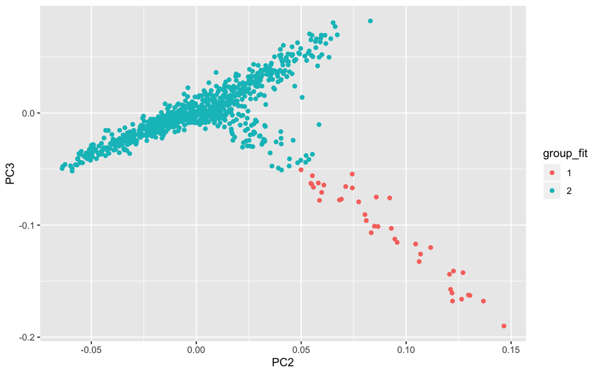

```r
km <- kmeans(pca_combined$rotation[, 1:3], 2, iter.max=1e3, nstart=100)
km_fit <- fitted(km, method="classes")
data_combined[["group_fit"]] <- as.factor(km_fit)

ggplot(data_combined) + aes(x=PC2, y=PC3, color=group_fit) + geom_point()
```

Another way to explore the result of k-means is to look at the articles that are most characteristic of each cluster. First, calculate the sum of squared residuals for each article.

```r
km_residual <- pca_combined$rotation[, 1:3] - fitted(km)
km_ss_residual <- apply(km_residual, 1, var)
data_combined[["err"]] <- km_ss_residual
```

Now we can identify the articles within each group that have the smallest residuals. These are closest to the group center, and thus most characteristic of the group.

```r
data_ordered <- data_combined[order(data_combined[["err"]]),]
head(data_ordered[["title"]][data_ordered[["group_fit"]] == 1])
```

```
## [1] Consistent high viral load of human papillomavirus 16 and risk of cervical carcinoma in situ: a nested case-control study.
## [2] Final efficacy, immunogenicity, and safety analyses of a nine-valent human papillomavirus vaccine in women aged 16-26 years: a randomised, double-blind trial.
## [3] HPV 16 DNA in normal and malignant cervical epithelium: implications for the aetiology and behaviour of cervical neoplasia.
## [4] Human papillomavirus DNA testing for the detection of cervical intraepithelial neoplasia grade 3 and cancer: 5-year follow-up of a randomised controlled implementation trial.
## [5] Progressive potential of mild cervical atypia: prospective cytological, colposcopic, and virological study.
## [6] Human papillomavirus type 16 in cervical smears as predictor of high-grade cervical intraepithelial neoplasia [corrected].
## 855 Levels: “Choosing wisely”: The American society for radiation oncology's top 5 list. ...
```

```r
head(data_ordered[["title"]][data_ordered[["group_fit"]] == 2])
```

```
## [1] Primary radiation therapy for early breast cancer: The experience at the joint center for radiation therapy.
## [2] Long-term cosmesis and toxicity profile following accelerated partial breast irradiation (APBI): Final analysis of the american society of breast surgeons breast brachytherapy registry trial.
## [3] Primary breast irradiation in large-breasted or heavy women: Analysis of cosmetic outcome.
## [4] Non-white women are as likely as white women to receive hypofractionated radiation therapy for breast cancer, but less likely to enroll in hypofractionation clinical trials.
## [5] Highly Accelerated Irradiation in 5 Fractions (HAI-5): Feasibility in Elderly Women With Early or Locally Advanced Breast Cancer.
## [6] Utilization of hypofractionated regimens for treatment of breast cancer in an insured population before and after initiation of astro's “choosing wisely” campaign.
## 855 Levels: “Choosing wisely”: The American society for radiation oncology's top 5 list. ...
```

Dr. Pamela Reynolds, Arthur Koehl, Dr. Wesley Brooks

February 10, 2020